# Homework 2

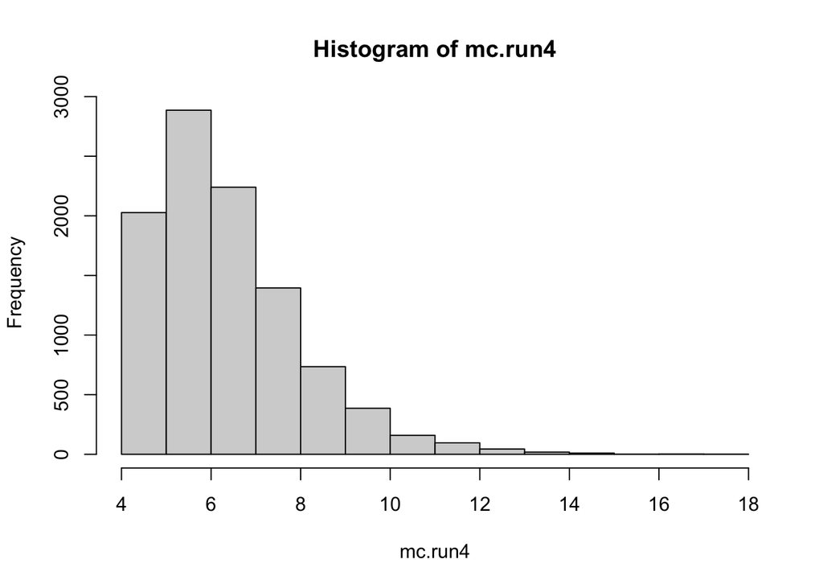

```r
hist(mc.run4)
```

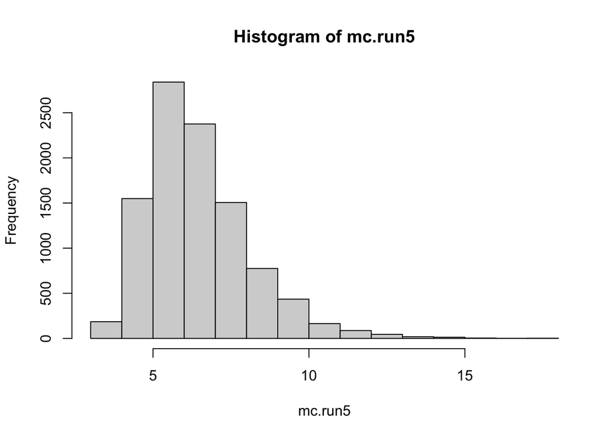

```r
hist(mc.run5)
```

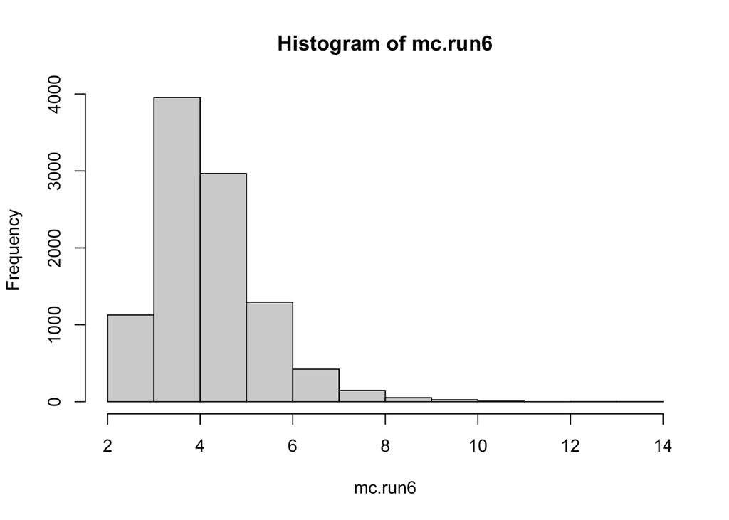

```r
hist(mc.run6)
```

flip5 is ruled out by common sense, almost impossible to flip this many heads or tails in a row. flip1 is also ruled out by common sense, this pattern is almost impossible to generate. flip6 is also ruled out because there are too many consecutive sequence of heads and tails. flips4 is also ruled out due to containing a sequence 9 consecutive tails in a row, which is deemed unlikely. Out of all sequence, flip2 and flip3 are most likely to be randomly generated from independent flips of a fair coin but flip2’s bar graph shows that the longest run value should be around 6-7 but upon calculation, we found that it’s 3. Therefore, in the end, the sequence that is most likely tobe randomly generated from independent flips of a fair coin is flip3.